# Reproducible Research: Peer Assessment 1

## Loading and preprocessing the data

We start by reading the activity data from the csv file and transforming dates.

```r
data <- read.csv("activity.csv")
data$date <- as.Date(data$date, "%Y-%m-%d")
```

## What is mean total number of steps taken per day?

First, we compute the number of steps recorded by day and plot them as histogram.

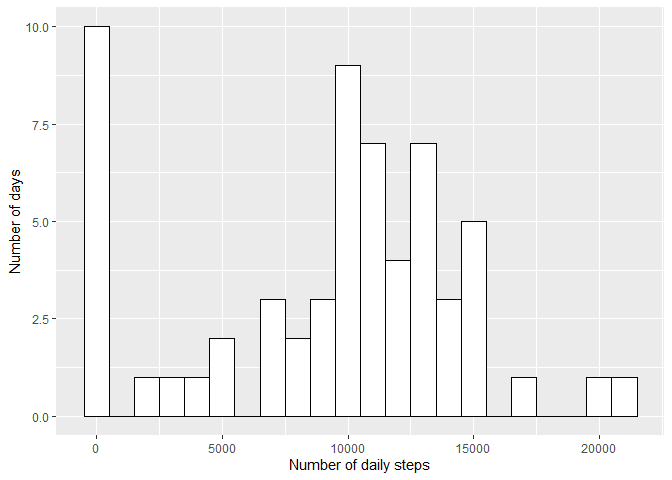

```r
daily.steps <- tapply(data$steps, data$date, sum, na.rm = TRUE)
daily.steps.df <- data.frame(date=names(daily.steps), daily.steps=daily.steps)
ggplot(daily.steps.df, aes(x=daily.steps)) + geom_histogram(color="black", fill="white", binwidth = 1000) + labs(x = "Number of daily steps", y = "Number of days")
```

The mean and median of daily number of steps are now computed.

```r
mean(daily.steps.df$daily.steps)
```

```
## [1] 9354.23
```

```r
median(daily.steps.df$daily.steps)
```

```
## [1] 10395
```

## What is the average daily activity pattern?

We plot the number of steps (averaged across all days) per 5-minute interval.

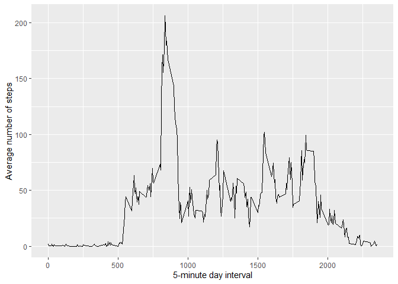

```r
ggplot(data, aes(x=interval, y=steps, group=1)) + stat_summary(fun.y = mean, geom='line', na.rm = TRUE ) + labs(x = "5-minute day interval", y = "Average number of steps")
```

We now find the 5-minute interval which, on average, contains the maximum number of steps.

```r
interval.steps <- tapply(data$steps, data$interval, mean, na.rm = TRUE)
interval.steps.df <- data.frame(interval=as.integer(names(interval.steps)), average.interval.steps=interval.steps)
max.interval.steps <- max(interval.steps.df$average.interval.steps)
interval.steps.df[which(interval.steps.df$average.interval.steps == max.interval.steps),]
```

```
##     interval average.interval.steps
## 835      835               206.1698
```

## Imputing missing values

The dataset contains several NAs. The total number of NAs is obtained below.

```r
sum(is.na(data$steps))
```

```
## [1] 2304
```

In order to fill the missing values, each NA is replaced by the mean for the corresponding 5-minute interval.

```r
replace.na.by.interval.mean = function(row, intervalsdata){
    if (is.na(row['steps'])){
        interval = as.integer(row['interval'])
        intervalsdata[intervalsdata['interval'] == interval,"average.interval.steps"]
    } else{
        as.integer(row['steps'])
    }
}
data.imputed <- data
data.imputed$steps <- apply(data.imputed, 1, replace.na.by.interval.mean, interval.steps.df)
```

We can now check that there is no NA in the new data frame.

```r
sum(is.na(data.imputed$steps))
```

```
## [1] 0
```

The histogram with imputed values can now be generated.

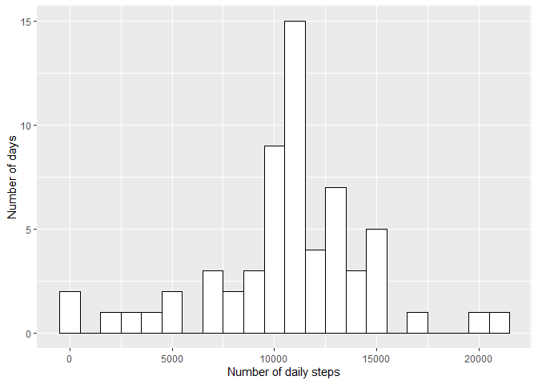

```r
daily.steps.imputed <- tapply(data.imputed$steps, data.imputed$date, sum, na.rm = TRUE)
daily.steps.imputed.df <- data.frame(date=names(daily.steps.imputed), daily.steps=daily.steps.imputed)
ggplot(daily.steps.imputed.df, aes(x=daily.steps)) + geom_histogram(color="black", fill="white", binwidth = 1000) + labs(x = "Number of daily steps", y = "Number of days")
```

The mean and median of daily number of steps with imputed missing values are now computed.

```r
mean(daily.steps.imputed.df$daily.steps)
```

```
## [1] 10766.19
```

```r
median(daily.steps.imputed.df$daily.steps)
```

```
## [1] 10766.19
```

The mean & median increased when imputing missing values, which is consistent with one’s expactations because NAs (counted as 0 in the previous results) are now replaced by the average interval values.

## Are there differences in activity patterns between weekdays and weekends?

We start by creating a factor variable indicating whether the day is weekday or weekend.

```r
weekends <- c("Saturday", "Sunday")
data.imputed$day.type <- as.factor(ifelse(weekdays(data.imputed$date) %in% weekends,"weekend","weekday"))
```

Finally, we can plot the activity patterns by 5-minute intervals averaged for weekdays and weekends.

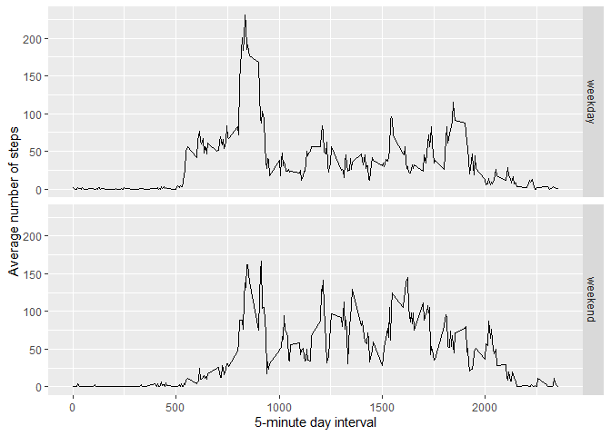

```r
ggplot(data=data.imputed, aes(x=interval, y = steps)) + stat_summary(fun.y = mean, geom='line') + facet_grid(day.type~.) + labs(x = "5-minute day interval", y = "Average number of steps")
```